# Transforming Probability Spaces

We can also use expectation values to evaluate pushforward interval probabilities,
$$\begin{align*}
(f_{n})_{*} \pi( \, (y_{1}, y_{2} ] \, )
&=
\mathbb{E}_{(f_{n})_{*} \pi} \left[ I_{(y_{1}, y_{2} ]} \right]
\\
&=
\mathbb{E}_{\pi} \left[ I_{(y_{1}, y_{2} ]} \circ f_{n} \right].
\end{align*}$$
These pushforward interval probabilities allow us to construct histogram representations of each pushforward probability distribution (Figure 19). The narrower the pushforward intervals we use, the more these histograms convey the same information that a pushforward probability density function would, especially when we scale the bin probabilities by the interval lengths as we discussed in [Chapter Six, Section 4.4](http://www.symplectomorphic.com/assets/chapters_html/density_functions.html#lebesgue-probability-densities-as-limiting-interval-probabilities).

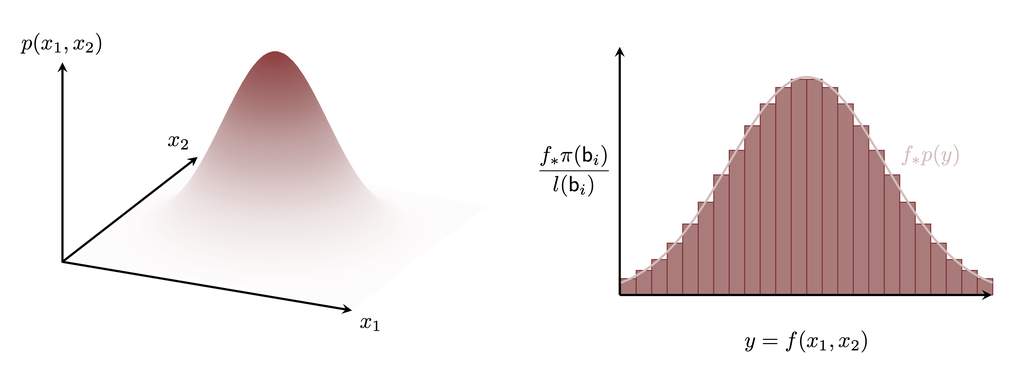

Figure 19: Pushforward histograms visualize similar information as pushforward probability density functions, especially when the binning is narrow, but are much easier to construct.

In theory, we can also use pushforward interval probabilities to construct the cumulative distribution functions for a given pushforward probability distribution by computing
$$\begin{align*}
P_{f_{*} \pi}(y)
&=
(f_{n})_{*} \pi( \, (-\infty, y] \, )
\\
&=
\mathbb{E}_{\pi} \left[ I_{(-\infty, y]} \circ f_{n} \right]
\end{align*}$$
for each $y \in \mathbb{R}$. Unfortunately, completely characterizing a pushforward cumulative distribution function in this way would require an infinite number of expectation value calculations, and typical computational budgets afford for only a finite number. In practice, we have to be content with *approximating* pushforward cumulative distribution functions (Figure 20).

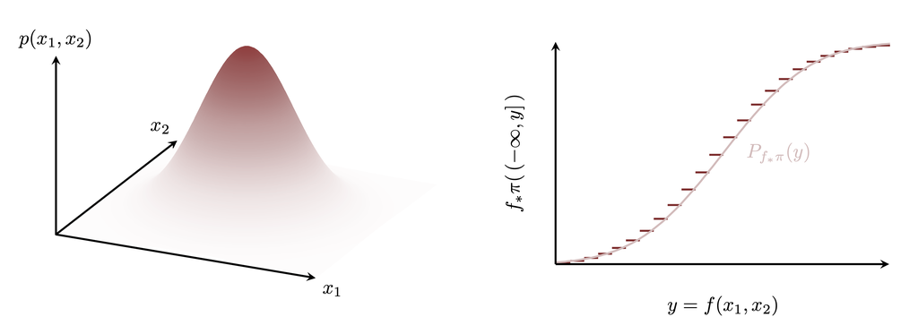

Figure 20: Aggregating pushforward bin probabilities allows us to approximately visualize a pushforward cumulative distribution function.

Lastly, we can often characterize one-dimensional pushforward probability distribution with nested pushforward quantile intervals (Figure 21). While we typically won’t be able to compute pushforward quantiles exactly, we can construct reasonable approximations to the $p$-th quantile by iteratively searching possible values $q_{p} \in \mathbb{R}$ until
$$| (f_{n})_{*} \pi( \, (-\infty, q_{p}] \, ) - p |
=
| \mathbb{E}_{\pi} \left[ I_{(-\infty, y]} \circ f_{n} \right] - p |$$
is sufficiently small.

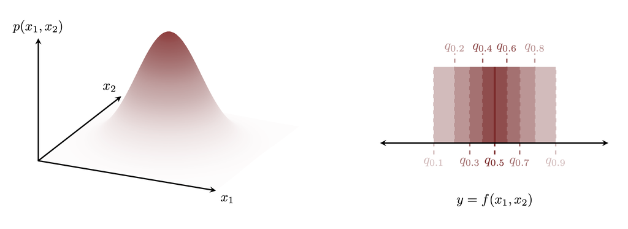

Figure 21: Nested quantile intervals provide a compact characterization of one-dimensional pushforward distributions.

I personally find histogram characterizations to be the most robust compromise between practical feasibility and visual information density, and we will be using them often in this book. Because they can be condensed into a single line, nested quantile intervals can also be convenient when visualizing many pushforward distributions at the same time (Figure 22). These visualizations are also know as **fan plots** or **ribbon plots**.

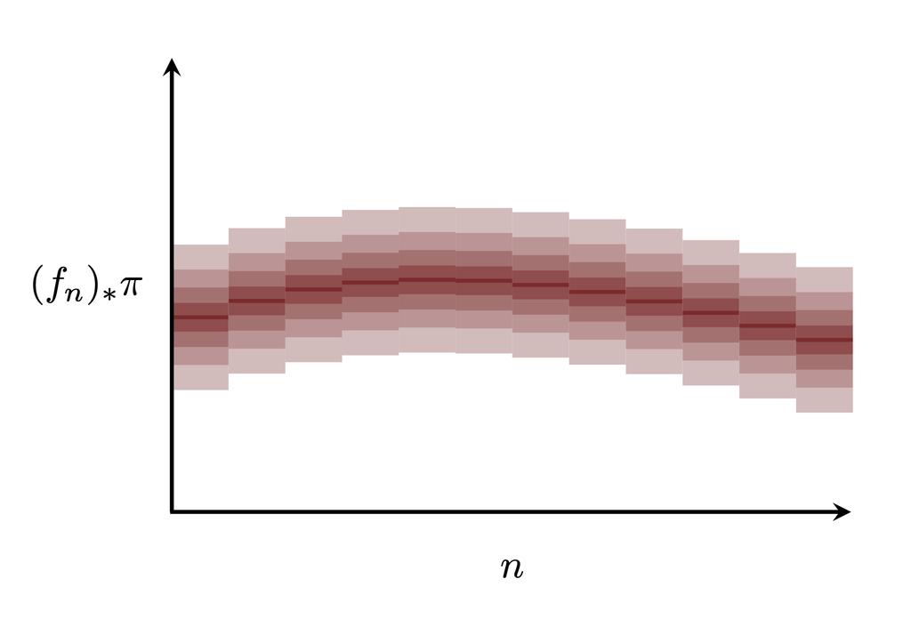

(a)

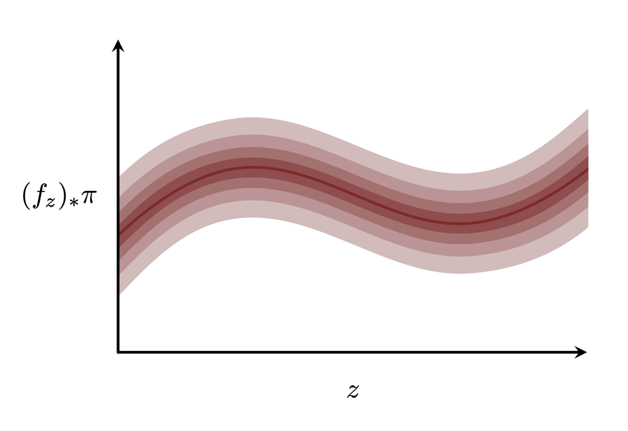

(b)

Figure 22: Nested quantile intervals are particularly useful for visualizing both (a) finite collections of summary functions that can be indexed by integers $n \in \mathbb{Z}$, and (b) uncountably infinite collections of summary functions that can be indexed by real numbers $z \in \mathbb{R}$. These visualizations are somewhat limited because they don’t convey the correlations between the summary function outputs. With that caveat in mind, however, they can be incredibly effective.

# 6 Conclusion

The ability to transform probabilistic objects, in particular the ability to actually implement these transformations in practice, is a critical tool in applied probability theory. These transformations allow us to not only manipulate probability spaces into more convenient forms, but also distill high-dimensional probabilistic information into low-dimensional summaries that are straightforward to visualize.

# Acknowledgements

A very special thanks to everyone supporting me on Patreon: Adam Fleischhacker, Adriano Yoshino, Alan Chang, Alessandro Varacca, Alexander Noll, Alexander Petrov, Alexander Rosteck, Andrea Serafino, Andrew Mascioli, Andrew Rouillard, Andrew Vigotsky, Angie_Hyunji Moon, Ara Winter, Austin Rochford, Austin Rochford, Avraham Adler, Ben Matthews, Ben Swallow, Benoit Essiambre, Bradley Kolb, Brandon Liu, Brendan Galdo, Brynjolfur Gauti Jónsson, Cameron Smith, Canaan Breiss, Cat Shark, Charles Naylor, Chase Dwelle, Chris, Chris Jones, Christopher Cahill, Christopher Mehrvarzi, Colin Carroll, Colin McAuliffe, Damien Mannion, Damon Bayer, dan mackinlay, Dan W Joyce, Dan Waxman, Dan Weitzenfeld, Daniel Edward Marthaler, Darshan Pandit, Darthmaluus , David Galley, David Wurtz, Denis Vlašiček, Doug Rivers, Dr. Jobo, Dr. Omri Har Shemesh, Dylan Maher, Ed Cashin, Edgar Merkle, Eric LaMotte, Ero Carrera, Eugene O’Friel, Felipe González, Fergus Chadwick, Finn Lindgren, Florian Wellmann, Francesco Corona, Geoff Rollins, Guido Biele, Hamed Bastan-Hagh, Haonan Zhu, Hector Munoz, Henri Wallen, herr, hs, Hugo Botha, Håkan Johansson, Ian, Ian Costley, idontgetoutmuch, Ignacio Vera, Ilaria Prosdocimi, Isaac Vock, J, J Michael Burgess, Jair Andrade, James C, James Hodgson, James Wade, Janek Berger, Jason Martin, Jason Pekos, Jason Wong, Jeff Burnett, Jeff Dotson, Jeff Helzner, Jeffrey Erlich, Jesse Wolfhagen, Jessica Graves, Joe Wagner, John Flournoy, Jonathan H. Morgan, Jonathon Vallejo, Joran Jongerling, Joshua Griffith, JU, Justin Bois, Karim Naguib, Karim Osman, Kejia Shi, Kristian Gårdhus Wichmann, Kádár András, Lars Barquist, lizzie , LOU ODETTE, Luís F, Marcel Lüthi, Marek Kwiatkowski, Mark Donoghoe, Markus P., Martin Modrák, Matt Moores, Matthew, Matthew Kay, Matthieu LEROY, Mattia Arsendi, Maurits van der Meer, Michael Colaresi, Michael DeWitt, Michael Dillon, Michael Lerner, Mick Cooney, Márton Vaitkus, N Sanders, N.S. , Name, Nathaniel Burbank, Nic Fishman, Nicholas Clark, Nicholas Cowie, Nick S, Octavio Medina, Oliver Crook, Olivier Ma, Patrick Kelley, Patrick Boehnke, Pau Pereira Batlle, Pieter van den Berg , ptr, Ramiro Barrantes Reynolds, Ravin Kumar, Raúl Peralta Lozada, Riccardo Fusaroli, Richard Nerland, Robert Frost, Robert Goldman, Robert kohn, Robin Taylor, Ryan Grossman, Rémi , S Hong, Scott Block, Sean Pinkney, Sean Wilson, Sergiy Protsiv, Seth Axen, shira, Simon Duane, Simon Lilburn, sssz, Stan_user, Stephanie Fitzgerald, Stephen Lienhard, Steve Bertolani, Stew Watts, Stone Chen, Susan Holmes, Svilup, Tao Ye, Tate Tunstall, Tatsuo Okubo, Teresa Ortiz, Theodore Dasher, Thomas Vladeck, Tiago Cabaço, Tim Radtke, Tobychev , Tom McEwen, Tomáš Frýda, Tony Wuersch, Virginia Fisher, Vitaly Druker, Vladimir Markov, Wil Yegelwel, Will Farr, Will Tudor-Evans, woejozney, yolhaj , Zach A, Zad Rafi, and Zhengchen Ca.

# References

Apostol, Tom M. 1969. *Calculus. Vol. II: Multi-Variable Calculus and Linear Algebra, with Applications to Differential Equations and Probability*. Second. Blaisdell Publishing Co. [Ginn; Co.], Waltham, Mass.-Toronto, Ont.-London.

Folland, G. B. 1999. *Real Analysis: Modern Techniques and Their Applications*. New York: John Wiley; Sons, Inc.

# License

The text and figures in this chapter are copyrighted by Michael Betancourt and licensed under the CC BY-NC 4.0 license:

https://creativecommons.org/licenses/by-nc/4.0/